# Lettuce Growth Optimization: Exploratory Data Analysis Case Study

Waldo Ketonou

February 13, 2026

```r
knitr::opts_chunk$set(
  echo = TRUE,
  message = FALSE,
  warning = FALSE,
  fig.align = "center",
  fig.width = 8,
  fig.height = 5
)

library(tidyverse)
library(lubridate)
library(ggplot2)
library(corrplot)
# library(GGally) # optional if you want pair plots later

# Load data (update path or source as needed)
lettuce <- read_csv("data/lettuce_cleaned_for_analysis.csv")
glimpse(lettuce)
```

```
## Rows: 3,169
## Columns: 24
## $ Plant_ID             <dbl> 1, 1, 1, 1, 1, 1, 1, 1, 1, 1, 1, 1, 1, 1, 1, 1, 1…
## $ Date                 <dttm> 2023-08-03, 2023-08-04, 2023-08-05, 2023-08-06, …
## $ Temperature          <dbl> 33.4, 33.5, 33.4, 33.4, 33.4, 32.3, 32.3, 22.7, 3…
## $ Humidity             <dbl> 53, 53, 59, 68, 74, 77, 75, 63, 69, 59, 77, 54, 7…
## $ TDS_ppm              <dbl> 582, 451, 678, 420, 637, 478, 682, 576, 662, 607,…
## $ pH                   <dbl> 6.4, 6.1, 6.4, 6.4, 6.5, 6.8, 6.0, 6.3, 6.1, 6.2,…
## $ Growth_Days          <dbl> 1, 2, 3, 4, 5, 6, 7, 8, 9, 10, 11, 12, 13, 14, 15…
## $ Temp_Change          <dbl> NA, 0.1, -0.1, 0.0, 0.0, -1.1, 0.0, -9.6, 9.2, -1…
## $ Humidity_Change      <dbl> NA, 0, 6, 9, 6, 3, -2, -12, 6, -10, 18, -23, 24, …
## $ pH_Change            <dbl> NA, -0.3, 0.3, 0.0, 0.1, 0.3, -0.8, 0.3, -0.2, 0.…
## $ TDS_Change           <dbl> NA, -131, 227, -258, 217, -159, 204, -106, 86, -5…
## $ Temp_Roll3           <dbl> NA, NA, 33.43333, 33.43333, 33.40000, 33.03333, 3…
## $ Humidity_Roll3       <dbl> NA, NA, 55.00000, 60.00000, 67.00000, 73.00000, 7…
## $ pH_Roll3             <dbl> NA, NA, 6.300000, 6.300000, 6.433333, 6.566667, 6…
## $ TDS_Roll3            <dbl> NA, NA, 570.3333, 516.3333, 578.3333, 511.6667, 5…
## $ Temp_Optimal         <lgl> FALSE, FALSE, FALSE, FALSE, FALSE, FALSE, FALSE, …
## $ Humidity_Optimal     <lgl> TRUE, TRUE, TRUE, TRUE, FALSE, FALSE, FALSE, TRUE…
## $ pH_Optimal           <lgl> TRUE, TRUE, TRUE, TRUE, TRUE, FALSE, TRUE, TRUE, …
## $ TDS_Optimal          <lgl> FALSE, FALSE, FALSE, FALSE, FALSE, FALSE, FALSE, …
## $ Temp_Optimal_num     <dbl> 0, 0, 0, 0, 0, 0, 0, 1, 0, 0, 0, 0, 0, 0, 0, 0, 0…
## $ Humidity_Optimal_num <dbl> 1, 1, 1, 1, 0, 0, 0, 1, 1, 1, 0, 1, 0, 1, 1, 1, 1…
## $ pH_Optimal_num       <dbl> 1, 1, 1, 1, 1, 0, 1, 1, 1, 1, 1, 1, 1, 1, 0, 1, 1…
## $ TDS_Optimal_num      <dbl> 0, 0, 0, 0, 0, 0, 0, 0, 0, 0, 0, 0, 0, 0, 0, 0, 0…
## $ Env_Score            <dbl> 0.50, 0.50, 0.50, 0.50, 0.25, 0.00, 0.25, 0.75, 0…
```

## 0.1 1. Business context and objectives

Hydroponic lettuce production is highly sensitive to environmental conditions such as temperature, humidity, nutrient concentration (TDS), and pH. Small deviations from optimal ranges can slow growth, increase variability, and reduce yield.

The goal of this analysis is to:

- **Understand** how environmental conditions behave over time.
- **Quantify** relationships between environmental factors and **Growth_Days**.
- **Evaluate** a composite **Env_Score** and optimal-condition flags as monitoring tools.
- **Generate insights** that can guide operational decisions to improve consistency and time-to-harvest.

This case study focuses on **exploratory data analysis (EDA)** as a foundation for future modeling and optimization.

## 0.2 2. Data overview

```r
# Basic structure
glimpse(lettuce)
```

```
## Rows: 3,169
## Columns: 24
## $ Plant_ID             <dbl> 1, 1, 1, 1, 1, 1, 1, 1, 1, 1, 1, 1, 1, 1, 1, 1, 1…
## $ Date                 <dttm> 2023-08-03, 2023-08-04, 2023-08-05, 2023-08-06, …
## $ Temperature          <dbl> 33.4, 33.5, 33.4, 33.4, 33.4, 32.3, 32.3, 22.7, 3…
## $ Humidity             <dbl> 53, 53, 59, 68, 74, 77, 75, 63, 69, 59, 77, 54, 7…
## $ TDS_ppm              <dbl> 582, 451, 678, 420, 637, 478, 682, 576, 662, 607,…
## $ pH                   <dbl> 6.4, 6.1, 6.4, 6.4, 6.5, 6.8, 6.0, 6.3, 6.1, 6.2,…
## $ Growth_Days          <dbl> 1, 2, 3, 4, 5, 6, 7, 8, 9, 10, 11, 12, 13, 14, 15…
## $ Temp_Change          <dbl> NA, 0.1, -0.1, 0.0, 0.0, -1.1, 0.0, -9.6, 9.2, -1…
## $ Humidity_Change      <dbl> NA, 0, 6, 9, 6, 3, -2, -12, 6, -10, 18, -23, 24, …
## $ pH_Change            <dbl> NA, -0.3, 0.3, 0.0, 0.1, 0.3, -0.8, 0.3, -0.2, 0.…
## $ TDS_Change           <dbl> NA, -131, 227, -258, 217, -159, 204, -106, 86, -5…
## $ Temp_Roll3           <dbl> NA, NA, 33.43333, 33.43333, 33.40000, 33.03333, 3…
## $ Humidity_Roll3       <dbl> NA, NA, 55.00000, 60.00000, 67.00000, 73.00000, 7…
## $ pH_Roll3             <dbl> NA, NA, 6.300000, 6.300000, 6.433333, 6.566667, 6…
## $ TDS_Roll3            <dbl> NA, NA, 570.3333, 516.3333, 578.3333, 511.6667, 5…
## $ Temp_Optimal         <lgl> FALSE, FALSE, FALSE, FALSE, FALSE, FALSE, FALSE, …
## $ Humidity_Optimal     <lgl> TRUE, TRUE, TRUE, TRUE, FALSE, FALSE, FALSE, TRUE…
## $ pH_Optimal           <lgl> TRUE, TRUE, TRUE, TRUE, TRUE, FALSE, TRUE, TRUE, …
## $ TDS_Optimal          <lgl> FALSE, FALSE, FALSE, FALSE, FALSE, FALSE, FALSE, …
## $ Temp_Optimal_num     <dbl> 0, 0, 0, 0, 0, 0, 0, 1, 0, 0, 0, 0, 0, 0, 0, 0, 0…
## $ Humidity_Optimal_num <dbl> 1, 1, 1, 1, 0, 0, 0, 1, 1, 1, 0, 1, 0, 1, 1, 1, 1…
## $ pH_Optimal_num       <dbl> 1, 1, 1, 1, 1, 0, 1, 1, 1, 1, 1, 1, 1, 1, 0, 1, 1…
## $ TDS_Optimal_num      <dbl> 0, 0, 0, 0, 0, 0, 0, 0, 0, 0, 0, 0, 0, 0, 0, 0, 0…
## $ Env_Score            <dbl> 0.50, 0.50, 0.50, 0.50, 0.25, 0.00, 0.25, 0.75, 0…
```

```r
# Summary of key numeric variables
lettuce %>%
  select(where(is.numeric)) %>%
  summary()
```

```
##     Plant_ID      Temperature       Humidity        TDS_ppm          pH
##  Min.   : 1.00   Min.   :18.00   Min.   :50.00   Min.   :400   Min.   :6.000
##  1st Qu.:18.00   1st Qu.:23.60   1st Qu.:57.00   1st Qu.:498   1st Qu.:6.200
##  Median :35.00   Median :30.20   Median :65.00   Median :593   Median :6.400
##  Mean   :35.44   Mean   :28.14   Mean   :64.87   Mean   :598   Mean   :6.399
##  3rd Qu.:53.00   3rd Qu.:31.50   3rd Qu.:73.00   3rd Qu.:699   3rd Qu.:6.600
##  Max.   :70.00   Max.   :33.50   Max.   :80.00   Max.   :800   Max.   :6.800
##
##   Growth_Days     Temp_Change       Humidity_Change       pH_Change
##  Min.   : 1.00   Min.   :-9.70000   Min.   :-30.00000   Min.   :-8.0e-01
##  1st Qu.:12.00   1st Qu.:-0.70000   1st Qu.: -9.00000   1st Qu.:-2.0e-01
##  Median :23.00   Median : 0.00000   Median :  0.00000   Median : 0.0e+00
##  Mean   :23.14   Mean   :-0.02694   Mean   :  0.05647   Mean   : 3.2e-05
##  3rd Qu.:34.00   3rd Qu.: 0.40000   3rd Qu.:  9.00000   3rd Qu.: 2.0e-01
##  Max.   :48.00   Max.   :11.00000   Max.   : 30.00000   Max.   : 8.0e-01
##                  NA's   :70         NA's   :70          NA's   :70
##    TDS_Change          Temp_Roll3    Humidity_Roll3     pH_Roll3
##  Min.   :-398.0000   Min.   :18.37   Min.   :50.33   Min.   :6.033
##  1st Qu.:-114.0000   1st Qu.:23.10   1st Qu.:61.00   1st Qu.:6.300
##  Median :  -4.0000   Median :30.10   Median :64.67   Median :6.400
##  Mean   :  -0.0668   Mean   :28.08   Mean   :64.88   Mean   :6.399
##  3rd Qu.: 118.0000   3rd Qu.:30.97   3rd Qu.:68.67   3rd Qu.:6.500
##  Max.   : 391.0000   Max.   :33.43   Max.   :79.00   Max.   :6.800
##  NA's   :70          NA's   :140     NA's   :140     NA's   :140
##    TDS_Roll3     Temp_Optimal_num Humidity_Optimal_num pH_Optimal_num
##  Min.   :411.7   Min.   :0.000    Min.   :0.0000       Min.   :0.0000
##  1st Qu.:550.0   1st Qu.:0.000    1st Qu.:0.0000       1st Qu.:0.0000
##  Median :596.7   Median :0.000    Median :1.0000       Median :1.0000
##  Mean   :597.7   Mean   :0.266    Mean   :0.6737       Mean   :0.6873
##  3rd Qu.:645.3   3rd Qu.:1.000    3rd Qu.:1.0000       3rd Qu.:1.0000
##  Max.   :779.3   Max.   :1.000    Max.   :1.0000       Max.   :1.0000
##  NA's   :140
##  TDS_Optimal_num      Env_Score
##  Min.   :0.000000   Min.   :0.0000
##  1st Qu.:0.000000   1st Qu.:0.2500
##  Median :0.000000   Median :0.5000
##  Mean   :0.002524   Mean   :0.4074
##  3rd Qu.:0.000000   3rd Qu.:0.5000
##  Max.   :1.000000   Max.   :1.0000
##
```

### 0.2.1 2.1 Missing values

```r
lettuce %>%
  summarise(across(everything(), ~sum(is.na(.)))) %>%
  pivot_longer(cols = everything(), names_to = "Variable", values_to = "Missing_Count") %>%
  arrange(desc(Missing_Count))
```

| Variable | Missing_Count |
| --- | --- |
| Temp_Roll3 | 140 |
| Humidity_Roll3 | 140 |
| pH_Roll3 | 140 |
| TDS_Roll3 | 140 |
| Temp_Change | 70 |
| Humidity_Change | 70 |
| pH_Change | 70 |
| TDS_Change | 70 |
| Plant_ID | 0 |
| Date | 0 |

[output cut: 14 more lines]

## 0.3 3. Distribution of key variables

### 0.3.1 3.1 Environmental variables

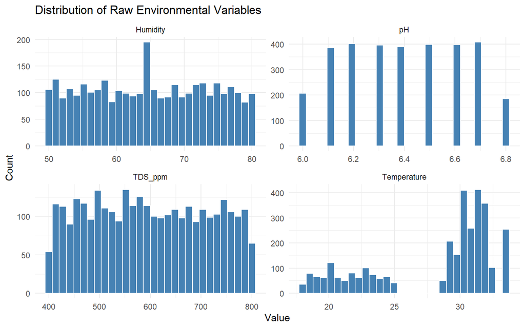

Distribution of raw environmental variables

```r
lettuce %>%
  select(Temperature, Humidity, TDS_ppm, pH) %>%
  pivot_longer(cols = everything(),
               names_to = "Variable",
               values_to = "Value") %>%
  ggplot(aes(x = Value)) +
  geom_histogram(bins = 30, fill = "steelblue", color = "white") +
  facet_wrap(~Variable, scales = "free") +
  theme_minimal() +
  labs(
    title = "Distribution of Raw Environmental Variables",
    x = "Value",
    y = "Count"
  )
```

### 0.3.2 3.2 Growth days

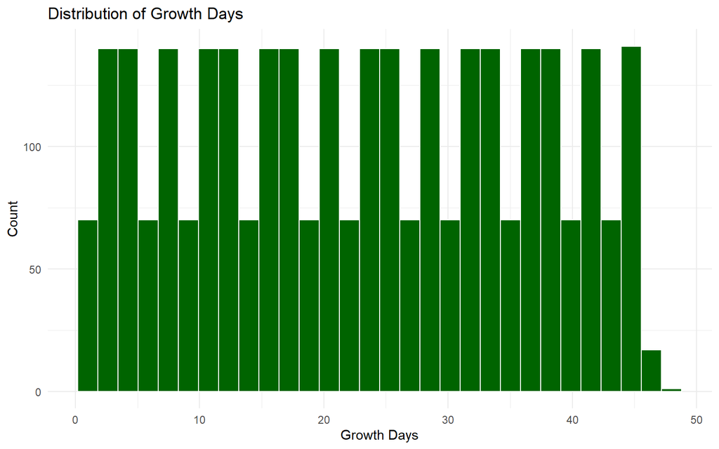

Distribution of Growth_Days

```r
ggplot(lettuce, aes(x = Growth_Days)) +
  geom_histogram(bins = 30, fill = "darkgreen", color = "white") +
  theme_minimal() +
  labs(
    title = "Distribution of Growth Days",
    x = "Growth Days",
    y = "Count"
  )
```

## 0.4 4. Time-series behavior and rolling averages

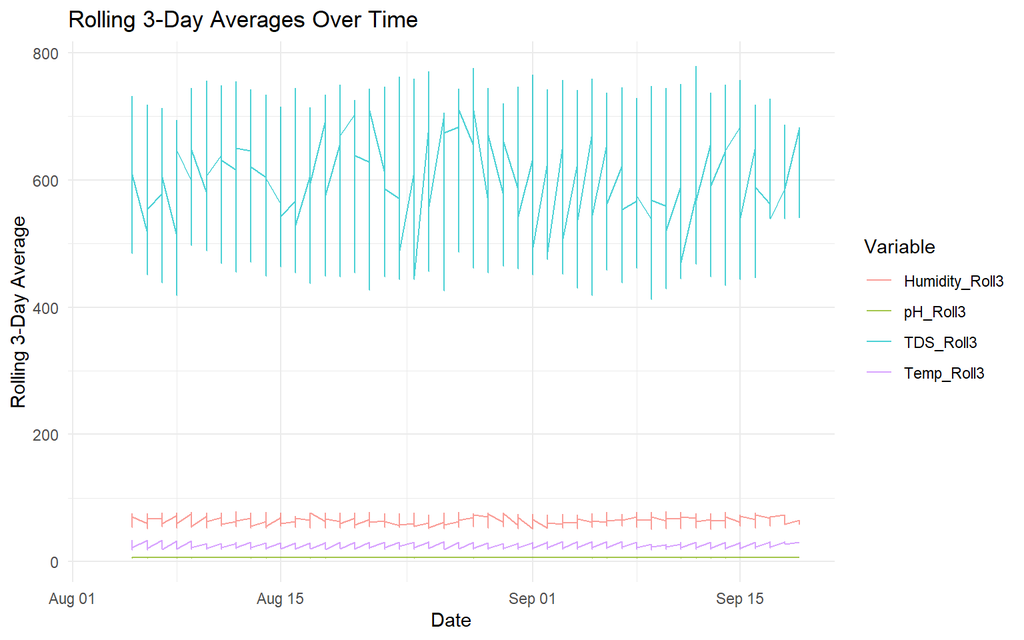

Rolling 3-day averages over time

```r
lettuce %>%
  pivot_longer(cols = ends_with("Roll3"),
               names_to = "Variable",
               values_to = "Value") %>%
  ggplot(aes(x = Date, y = Value, color = Variable)) +
  geom_line(alpha = 0.7) +
  theme_minimal() +
  labs(
    title = "Rolling 3-Day Averages Over Time",
    x = "Date",
    y = "Rolling 3-Day Average"
  )
```

**Interpretation (example):**  
Rolling averages smooth out short-term noise and highlight broader trends or shifts in environmental control. Periods of instability or drift may correspond to operational changes or equipment issues.

## 0.5 5. Correlation structure

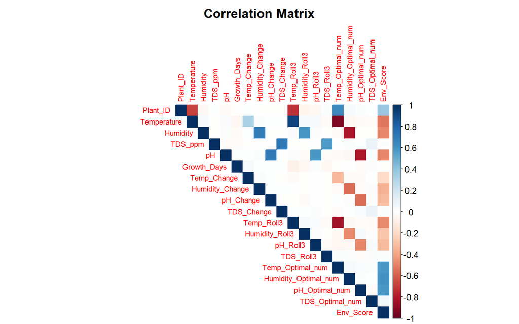

Correlation matrix of numeric variables

```r
numeric_vars <- lettuce %>%
  select(where(is.numeric))

cor_matrix <- cor(numeric_vars, use = "complete.obs")

corrplot(cor_matrix,
         method = "color",
         type = "upper",
         tl.cex = 0.7,
         title = "Correlation Matrix",
         mar = c(0, 0, 2, 0))
```

**Interpretation (example):**  
The correlation matrix reveals how environmental variables relate to each other and to Growth_Days. Strong correlations may indicate redundancy or potential multicollinearity in future models, while weak correlations suggest more independent effects.

## 0.6 6. Environmental score and growth performance

### 0.6.1 6.1 Env_Score vs Growth_Days

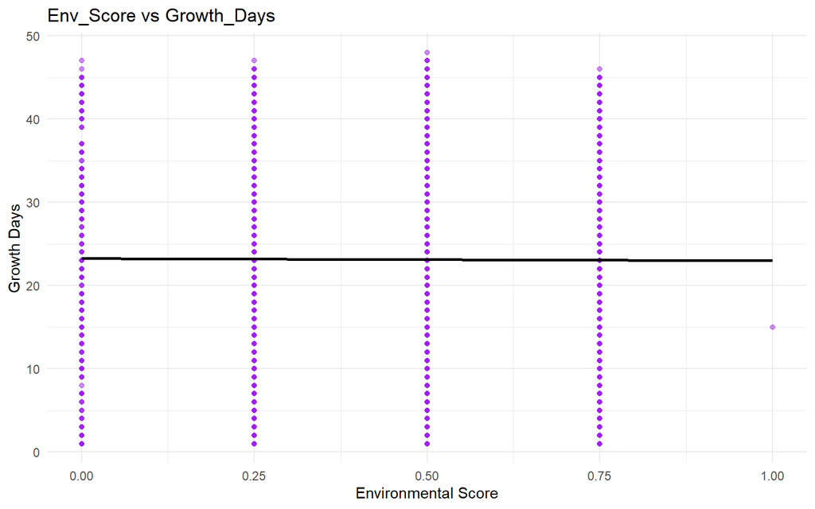

Env_Score vs Growth_Days

```r
ggplot(lettuce, aes(x = Env_Score, y = Growth_Days)) +
  geom_point(alpha = 0.5, color = "purple") +
  geom_smooth(method = "lm", se = FALSE, color = "black") +
  theme_minimal() +
  labs(
    title = "Env_Score vs Growth_Days",
    x = "Environmental Score",
    y = "Growth Days"
  )
```

**Interpretation (example):**  
The trend line provides an initial view of whether better environmental scores are associated with shorter (or longer) Growth_Days. This validates whether Env_Score is a meaningful composite metric for operational monitoring.

## 0.7 7. Optimal condition flags

### 0.7.1 7.1 Proportion of optimal conditions over time

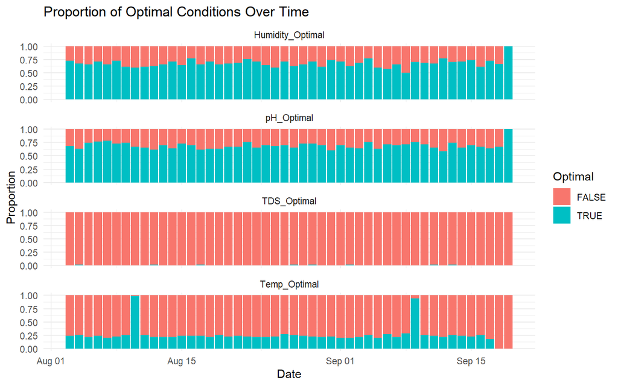

Proportion of optimal conditions over time

```r
lettuce %>%
  select(Date, Temp_Optimal, Humidity_Optimal, pH_Optimal, TDS_Optimal) %>%
  pivot_longer(cols = -Date,
               names_to = "Condition",
               values_to = "Optimal") %>%
  ggplot(aes(x = Date, fill = Optimal)) +
  geom_bar(position = "fill") +
  facet_wrap(~Condition, ncol = 1) +
  theme_minimal() +
  labs(
    title = "Proportion of Optimal Conditions Over Time",
    x = "Date",
    y = "Proportion"
  )
```